# mega_project_deep_learning_cnn_v2_2

#### Version 2.1

The project I am working on requires me to build and hopefully deploy a machine learning model. I am part of the TIA group, which focuses on the waste management problem in South Africa.

My group's solution is mainly around the idea of a smart bin.

The algorithm I will be using in this project is Deep Learning's Convolutional Neural Network. Which is widely used and praised for its accuracy and performance on image classification. In this project, I will be classifying images of waste.

#### Import the essential packages that will be used.

```python
# deep learning
from keras.models import Sequential
from keras.layers import Conv2D, MaxPooling2D
from keras.layers import Activation, Dropout, Flatten, Dense
from keras.callbacks import EarlyStopping, ModelCheckpoint

# saving model
import pickle

# visualization
import matplotlib.pyplot as plt
import scipy
import seaborn as sns
from keras.utils.vis_utils import plot_model

# processing and data generation
import numpy as np
from keras.preprocessing.image import ImageDataGenerator
from keras.preprocessing import image
from keras import backend
```

#### Directory and define the labels/features

```python
# set the image dimenions, all images will have height & width set to 256x256
img_width, img_height = 256, 256

# directory
train_data_dir = 'organic_and_recyclable/'
test_data_dir = 'organic_and_recyclable/'

# we will use the 70/30 split here. So 30% of the 671 will be used for testing. Which is about 200 samples.
nb_train_samples = 471
nb_test_samples = 200

# An epoch elapses when an entire dataset is passed forward and backward through the neural network exactly one time
epochs = 50

# Batch size is the total number of training samples present in a single mini-batch
batch_size = 128
```

#### Clean data

Here we are checking if the image is in the right format. For our model we will use RGB, since its waste images, it wiser to keep the color of the images as well. With dimensions 256 x 256.

ref: https://www.tensorflow.org/api_docs/python/tf/keras/preprocessing/image/ImageDataGenerator ref: https://www.codesofinterest.com/2017/09/keras-image-data-format.html

The image_data_format parameter affects how each of the backends treat the data dimensions when working with multi-dimensional convolution layers. Specifically, it defines where the 'channels' dimension is in the input data.

For tensorflow backend, the image data format is channels_last.

```python
print(backend.image_data_format())

# To know your backend go to the keras.json which can be found at %USERPROFILE%\.keras\keras.json on Windows.
# {
#     "floatx": "float32",
#     "epsilon": 1e-07,
#     "backend": "tensorflow",
#     "image_data_format": "channels_last"
# }

# because image data format is channels_last, we will set the input_shape to that.
input_shape = (img_width, img_height, 3)
```

```
channels_last
```

#### Generate training and tests sets

The ImageDataGenerator generates batches of image data with real-time data augmentation. The data will be looped over (in batches). ImageDataGenerator allows us to do data augmentation, which is commonly used with image data. For example, we can flip the image, we can set the rortation range, and zoom into the image.

ref: https://vijayabhaskar96.medium.com/tutorial-on-keras-imagedatagenerator-with-flow-from-dataframe-8bd5776e45c1 ref: https://www.tensorflow.org/api_docs/python/tf/keras/preprocessing/image/ImageDataGenerator#flow_from_directory

```python
# Data augmentation - Preprocessing
train_data_gen = ImageDataGenerator(rotation_range = 40, width_shift_range=0.2,
                                    height_shift_range=0.2, rescale = 1. / 255,
                                    shear_range = 0.2, zoom_range = 0.2,
                                    horizontal_flip = True, vertical_flip=True)
```

```python
# preprocessing the test set
test_data_gen = ImageDataGenerator(rescale = 1. / 255)
```

Below you can see, they are 671 images in total for the training and test data belonging to the two classes. We have set class_mode to binary because we have a binary problem. Remember the two classes (0 and 1). Also, we have set the target size to our preferred size 256 x 256 and set the color_mode to rgb. In addition, we defined the batch size, if you can remember we are using 128 as our batch size.

```python
train_generator = train_data_gen.flow_from_directory(
    train_data_dir, target_size=(img_width, img_height), color_mode="rgb", batch_size = batch_size, class_mode = 'binary')
```

```
Found 671 images belonging to 2 classes.
```

```python
test_generator = test_data_gen.flow_from_directory(
    test_data_dir, target_size=(img_width, img_height), color_mode="rgb", batch_size = batch_size, class_mode = 'binary')
```

```
Found 671 images belonging to 2 classes.
```

Below you can see the 2 classes we will be using in the model. Class O for Organic (0) and Class R for Recyclable (1)

```python
print('Training data: ', train_generator.class_indices)
print('Testing data: ', test_generator.class_indices)
```

```
Training data:  {'O': 0, 'R': 1}
Testing data:  {'O': 0, 'R': 1}
```

#### Create neural network

Create neural network with Keras's Sequential.

- We are not using 3D image data, so, let's just stick to the standard Conv2D.
- Maxpooling2D: Downsamples the input along its spatial dimensions (height and width) by taking the maximum value over an input window (of size defined by pool_size) for each channel of the input.
- Activation function RELU: ReLU is linear (identity) for all positive values, and zero for all negative values. This means that:
  - It’s cheap to compute as there is no complicated math. The model can therefore take less time to train or run.
  - It converges faster. Linearity means that the slope doesn’t plateau, or “saturate,” when x gets large. It doesn’t have the vanishing gradient problem suffered by other activation functions like sigmoid or tanh.
  - It’s sparsely activated. Since ReLU is zero for all negative inputs, it’s likely for any given unit to not activate at all. This is often desirable.

ref: https://keras.io/api/models/sequential/ ref: https://www.ibm.com/cloud/learn/convolutional-neural-networks#toc-convolutio-JgBTyG9C ref: https://towardsdatascience.com/a-comprehensive-guide-to-convolutional-neural-networks-the-eli5-way-3bd2b1164a53 ref: https://www.tensorflow.org/tutorials/images/classification ref: https://keras.io/api/layers/convolution_layers/convolution2d/ ref: https://medium.com/analytics-vidhya/a-guide-to-neural-network-layers-with-applications-in-keras-40ccb7ebb57a ref: https://www.upgrad.com/blog/basic-cnn-architecture/ ref: https://www.geeksforgeeks.org/activation-functions-neural-networks/ ref: https://www.baeldung.com/cs/ml-relu-dropout-layers#:~:text=The%20Dropout%20layer%20is%20a%20mask%20that%20nullifies,in%20which%20case%20it%20nullifies%20some%20hidden%20neurons. ref: https://tiddler.github.io/optimizers/

```python
# create Sequential object
model = Sequential()

# Add a Convolutional layer
# 32 are the number of output filters in the convolution,
# (3,3) is tuple/list of a single integer, specifying the length of the 1D convolution window
model.add(Conv2D(32, (3, 3), input_shape=input_shape))
# Activation function is relu
model.add(Activation('relu'))
# Adding our max pooling layer
model.add(MaxPooling2D(pool_size=(2, 2)))

# Add a Convolutional layer
model.add(Conv2D(32, (3, 3)))
# Activation function is relu
model.add(Activation('relu'))
# Adding our max pooling layer
model.add(MaxPooling2D(pool_size=(2, 2)))

# Add a Convolutional layer
model.add(Conv2D(64, (3, 3)))
# Activation function is relu
model.add(Activation('relu'))
# ading our max pooling layer
model.add(MaxPooling2D(pool_size=(2, 2)))

# Add a Convolutional layer
model.add(Conv2D(128, (3, 3)))
# Activation function is relu
model.add(Activation('relu'))
# ading our max pooling layer
model.add(MaxPooling2D(pool_size=(2, 2)))

# Add a Convolutional layer
model.add(Conv2D(64, (3, 3)))
# Activation function is relu
model.add(Activation('relu'))
# ading our max pooling layer
model.add(MaxPooling2D(pool_size=(2, 2)))

# Adding Our flattening Layer (flatten the image from 2d to 1d image)
model.add(Flatten())

# Fully Connected Layer
model.add(Dense(32))
# Activation function is relu
model.add(Activation('relu'))

# Dropout layers are important in training CNNs because they prevent overfitting on the training data
model.add(Dropout(0.5))

# Add the output layer, one output, whether 0 or 1, sigmoid activation makes this possible
model.add(Dense(1))
# Activation function is sigmoid
model.add(Activation('sigmoid'))
```

#### Summary

ref: https://www.machinecurve.com/index.php/2020/04/01/how-to-generate-a-summary-of-your-keras-model/ ref: https://izziswift.com/keras-model-summary-result-understanding-the-of-parameters/ ref: https://machinelearningmastery.com/visualize-deep-learning-neural-network-model-keras/#:~:text=Keras%20provides%20a%20way%20to%20summarize%20a%20model.,the%20model.%20The%20output%20shape%20of%20each%20layer.

```python
# Show what was the neural network has done
model.summary()
```

```
Model: "sequential"
_________________________________________________________________
Layer (type)                 Output Shape              Param #
=================================================================
conv2d (Conv2D)              (None, 254, 254, 32)      896
_________________________________________________________________
activation (Activation)      (None, 254, 254, 32)      0
_________________________________________________________________
max_pooling2d (MaxPooling2D) (None, 127, 127, 32)      0
_________________________________________________________________
conv2d_1 (Conv2D)            (None, 125, 125, 32)      9248
_________________________________________________________________
activation_1 (Activation)    (None, 125, 125, 32)      0
_________________________________________________________________
max_pooling2d_1 (MaxPooling2 (None, 62, 62, 32)        0
_________________________________________________________________
conv2d_2 (Conv2D)            (None, 60, 60, 64)        18496
_________________________________________________________________
activation_2 (Activation)    (None, 60, 60, 64)        0
_________________________________________________________________
max_pooling2d_2 (MaxPooling2 (None, 30, 30, 64)        0
_________________________________________________________________
conv2d_3 (Conv2D)            (None, 28, 28, 128)       73856
_________________________________________________________________
activation_3 (Activation)    (None, 28, 28, 128)       0
_________________________________________________________________
max_pooling2d_3 (MaxPooling2 (None, 14, 14, 128)       0
_________________________________________________________________
conv2d_4 (Conv2D)            (None, 12, 12, 64)        73792
_________________________________________________________________
activation_4 (Activation)    (None, 12, 12, 64)        0
_________________________________________________________________
max_pooling2d_4 (MaxPooling2 (None, 6, 6, 64)          0
_________________________________________________________________
flatten (Flatten)            (None, 2304)              0
_________________________________________________________________
dense (Dense)                (None, 32)                73760
_________________________________________________________________
activation_5 (Activation)    (None, 32)                0
_________________________________________________________________
dropout (Dropout)            (None, 32)                0
_________________________________________________________________
dense_1 (Dense)              (None, 1)                 33
_________________________________________________________________
activation_6 (Activation)    (None, 1)                 0
=================================================================
Total params: 250,081
Trainable params: 250,081
Non-trainable params: 0
_________________________________________________________________
```

The size of input images are 256x256. We used 3x3 filters so the size of feature maps are 254x254. The size is reduced to half in the first pooling layer. At each convolution-pooling layer pair, the size is reduced but features in the images are preserved (for example the 32, 64 and 128). In this model, we have more than 200k parameters to train, which is a lot.

If reading the summary is too much, we can visualize the architecture of our model and save it to a PNG file. To do that I used Keras's plot_model. (if you run into issues plottinf the model, you will have to install pydot and graphviz using 'pip' or 'conda'. I used 'conda' to install the packages and it worked.

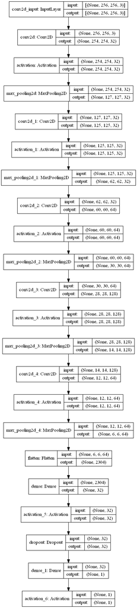

```python
plot_model(model, to_file='model_1.png', show_shapes=True, show_layer_names=True)
```